# Création de cartes choroplèthes avec {ggplot2}

# Solutions

**1. Construisez votre magnifique carte choroplèthe**

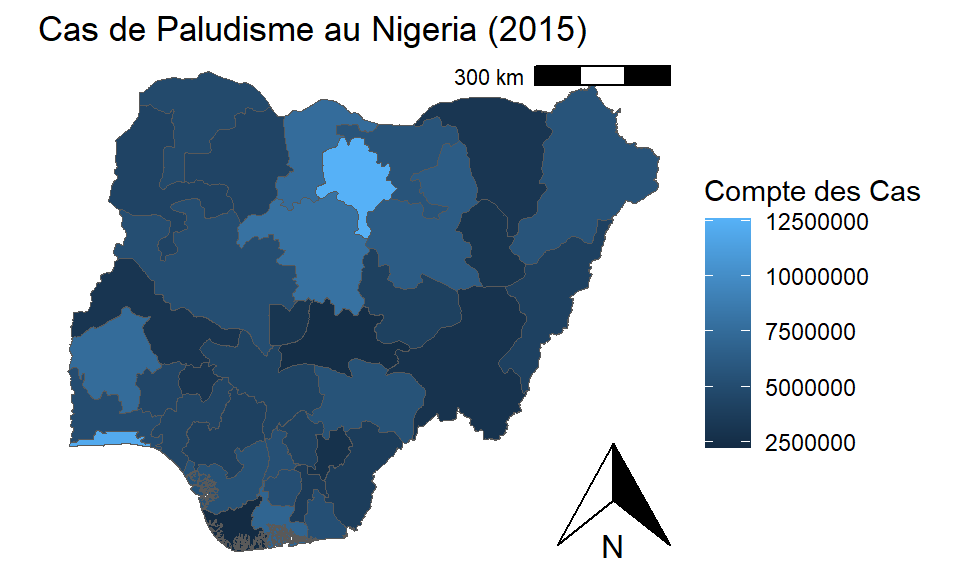

```r
ggplot(data=malaria2) +
  geom_sf(aes(fill=cases_2015)) +
  labs(title = "Cas de Paludisme au Nigeria (2015)",
       fill = "Compte des Cas",
       x = "Longitude",
       y = "Latitude") +
  ggspatial::annotation_north_arrow(location = "br")+
  ggspatial::annotation_scale(location = "tr")+
  theme_void()
```

**2. Créez votre propre palette de couleurs**

Créez votre propre palette de couleurs distincte de celle initialement fournie ci-dessous, et affichez les cas de paludisme à travers le Nigeria pour 2000 en utilisant cette palette de couleurs personnalisée. N’oubliez pas d’incorporer des améliorations esthétiques supplémentaires.

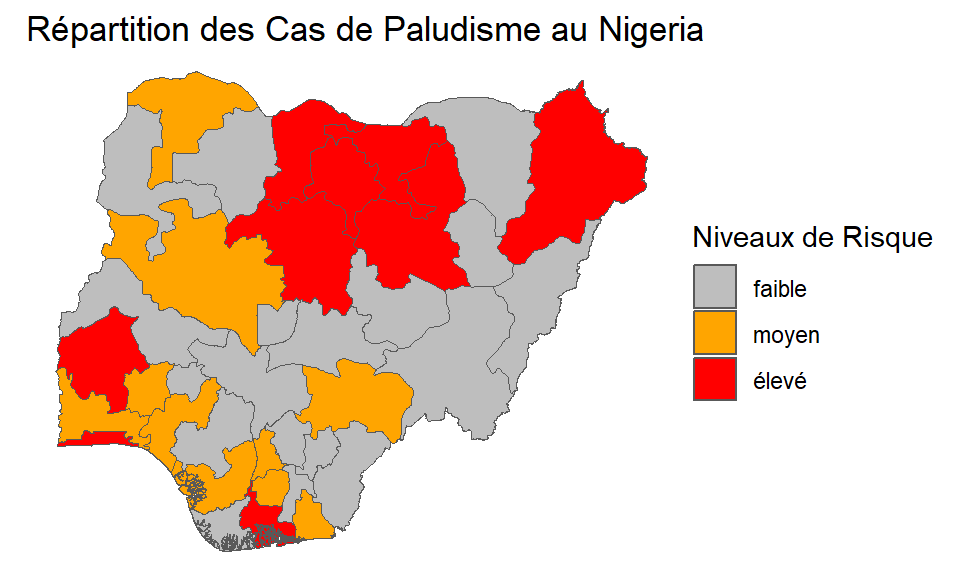

```r
new_palette <- c("grey", "orange", "red") # Définir un ensemble différent de couleurs
ggplot(data=malaria3) +
   geom_sf(aes(fill =  fct_reorder(risk, cases_2000))) + # Réordonner les étiquettes de risque selon les cas de l'année 2000
   scale_fill_manual(values = new_palette, "Niveaux de Risque") +
   labs(title = "Répartition des Cas de Paludisme au Nigeria",
        fill = "Compte des Cas",
        x = "Longitude",
        y = "Latitude") +
   coord_sf(expand = TRUE)+
   theme_void()
```

**3. Analysez la distribution des cas de paludisme**

Votre objectif est maintenant d’analyser la distribution des cas de paludisme au Nigeria pour les années 2000 et 2021. Mais vous devrez d’abord catégoriser les données en niveaux de risque en utilisant la médiane (haut/bas), puis visualiser ces informations sur une carte.

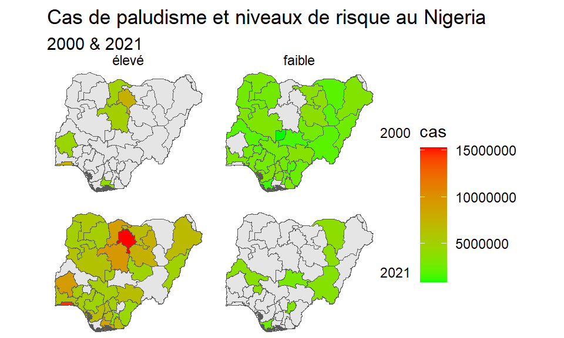

```r
# Pivotement des données
malaria3_longer <- malaria2 %>%
  pivot_longer(cols = `cases_2000`:`cases_2021`, names_to = "année", values_to = "cas")

# Catégorisation du risque basée sur la médiane
malaria3_longer %>%
  mutate(risk = case_when(
    cas <= median(cas) ~ 'faible',
    cas > median(cas) ~ 'élevé'
  )) -> malaria3_longer2

# Nettoyage des valeurs d'année
malaria3_longer2$année <- str_replace(malaria3_longer2$année, "cases_", "")

# Tracé des données
ggplot() +
  geom_sf(data = nga_adm1) +
  geom_sf(aes(fill = cas), data = filter(malaria3_longer2, année %in% c("2000", "2021"))) +
  facet_grid(année ~ risk) +
  coord_sf(expand = TRUE) +
  scale_fill_continuous(low = "green", high = "red") +
  labs(title = "Cas de paludisme et niveaux de risque au Nigeria",
       subtitle = "2000 & 2021") +
  xlab("Longitude") +
  ylab("Latitude") +
  theme_void()
```

# Contributeurs

Les membres de l’équipe suivants ont contribué à cette leçon :

- [IMAD EL BADISY](https://thegraphcourses.org/members/ielbadisy/)  
  Data Science Education Officer

  Deeply interested in health data
- [KENE DAVID NWOSU](https://thegraphcourses.org/members/kendavidn/)  
  Data analyst, the GRAPH Network

  Passionate about world improvement
- [JOY VAZ](https://thegraphcourses.org/members/joy)  
  R Developer and Instructor, the GRAPH Network

  Loves doing science and teaching science

# Références

- Wickham, Hadley, Winston Chang, and Maintainer Hadley Wickham. “Package ‘ggplot2’.” *Create elegant data visualisations using the grammar of graphics. Version* 2, no. 1 (2016): 1-189.
- Wickham, Hadley, Mine Çetinkaya-Rundel, and Garrett Grolemund. *R for data science*. ” O’Reilly Media, Inc.”, 2023.
- Lovelace, Robin, Jakub Nowosad, Jannes Muenchow. *Geocomputation with R*. CRC Press, 2019.

This work is licensed under the [Creative Commons Attribution Share Alike](https://creativecommons.org/licenses/by-sa/4.0/) license.